# **FORECASTING-FINAL PROJECT**

Hồ Đức Tuấn - MSSV: 23110054

# PHẦN 1: Bài tập lí thuyết

## Bài tập 1

$$\begin{aligned}
\text{Ta có: }
\gamma_{X}(s,t) &= \mathbb{E}[(X_s - \mu_s)(X_t-\mu_t)]\\
&=\mathbb{E}[X_sX_t - X_s\mu_t - X_t\mu_s + \mu_s\mu_t]\\
&=\mathbb{E}(X_sX_t)-\mathbb{E}(X_s\mu_t)-\mathbb{E}(X_t\mu_s)+\mu_s\mu_t\\
&= \mathbb{E}(X_sX_t)-\mu_s\mu_t-\mu_s\mu_t+\mu_s\mu_t\\
&= \mathbb{E}(X_sX_t)-\mu_s\mu_t \quad \text{(Điều phải chứng minh)}
\end{aligned}$$

## Bài tập 2

**a)**

$$\begin{aligned}
\text{Ta có: } X_t &= \beta_1 + \beta_2 t + W_t \\
\Rightarrow \mathbb{E}(X_t) &= \mathbb{E}(\beta_1 + \beta_2 t + W_t)
\\
&= \beta_1 + \beta_2 t \quad (\text{vì } \mathbb{E}(W_t) = 0) \\
\Rightarrow X_t \text{ không là } &\text{quá trình dừng vì }
\mathbb{E}(X_t) \text{ còn phụ thuộc vào } t
\end{aligned}$$

**b)**

$$\begin{aligned}
&\text{Ta có:}\quad Y_t = X_t - X_{t-1} \\
&\phantom{\text{Ta có:}}\quad = \beta_2 + W_t - W_{t-1} \\
&\text{Khi đó: } \gamma_Y(h) = Cov(Y_t, Y_{t+h}) \\
&\phantom{\text{Khi đó: }} = Cov(W_t - W_{t-1}, W_{t+h} - W_{t+h-1})
\\
&\phantom{\text{Khi đó: }} = Cov(W_t, W_{t+h}) - Cov(W_t, W_{t+h-1})
- Cov(W_{t-1}, W_{t+h}) + Cov(W_{t-1}, W_{t+h-1}) \\
&\text{Dựa vào tính chất của white noise } W_t \text{ có phương sai
} \sigma_W^2 \text{, ta xét các trường hợp của } h: \\
&\bullet h = 0: \gamma_Y(0) = Cov(W_t, W_t) + Cov(W_{t-1}, W_{t-1})
= \sigma_W^2 + \sigma_W^2 = 2\sigma_W^2 \\
&\bullet h = 1: \gamma_Y(1) = -Cov(W_t, W_t) = -\sigma_W^2 \\
&\bullet h = -1: \gamma_Y(-1) = -Cov(W_{t-1}, W_{t-1}) = -\sigma_W^2
\\
&\bullet |h| > 1: \gamma_Y(h) = 0 \\
&\text{Suy ra hàm autocovariance } \gamma_Y(h) \text{ chỉ phụ thuộc
vào } h, \text{ không phụ thuộc vào } t. \\
&\text{Kết luận: } Y_t \text{ là một quá trình dừng.}
\end{aligned}$$

**c)**

$$\begin{aligned}
&\text{1. Chứng minh hàm trung bình } \mu_{V_t} = \beta_1 + \beta_2
t: \\
&\text{Ta có: } V_t = \frac{1}{2q+1} \sum_{j=-q}^{q} X_{t-j} =
\frac{1}{2q+1} \sum_{j=-q}^{q} (\beta_1 + \beta_2(t-j) + W_{t-j}) \\
&\Rightarrow \mathbb{E}(V_t) = \frac{1}{2q+1} \sum_{j=-q}^{q}
(\beta_1 + \beta_2 t - \beta_2 j + \mathbb{E}(W_{t-j})) \\
&\phantom{\Rightarrow \mathbb{E}(V_t)} = \frac{1}{2q+1} \left[
\sum_{j=-q}^{q} \beta_1 + \sum_{j=-q}^{q} \beta_2 t - \beta_2
\sum_{j=-q}^{q} j + \sum_{j=-q}^{q} 0 \right] \\
&\text{Vì tổng đối xứng } \sum_{j=-q}^{q} j = 0 \text{ nên:} \\
&\Rightarrow \mathbb{E}(V_t) = \frac{(2q+1)\beta_1 + (2q+1)\beta_2
t}{2q+1} = \beta_1 + \beta_2 t \quad \text{(Điều phải chứng minh)} \\
\\
&\text{2. Tính hàm autocovariance } \gamma_V(h): \\
&\text{Ta có: } \gamma_V(h) = Cov(V_{t+h}, V_t). \text{ Do }
\beta_1, \beta_2 t \text{ là các thành phần tất định, nên:} \\
&\gamma_V(h) = Cov\left( \frac{1}{2q+1} \sum_{i=-q}^{q} W_{t+h-i},
\frac{1}{2q+1} \sum_{j=-q}^{q} W_{t-j} \right) \\
&\phantom{\gamma_V(h)} = \frac{1}{(2q+1)^2} \sum_{i=-q}^{q}
\sum_{j=-q}^{q} Cov(W_{t+h-i}, W_{t-j}) \\
&\text{Hiệp phương sai của white noise } Cov(W_a, W_b) = \sigma_W^2
\text{ nếu } a=b \text{, ngược lại bằng 0.} \\
&\text{Số cặp chỉ số trùng nhau } (t+h-i = t-j) \text{ là } (2q+1 -
|h|) \text{ với } |h| \le 2q. \\
&\text{Vậy: } \gamma_V(h) = \begin{cases}
\frac{(2q+1-|h|)\sigma_W^2}{(2q+1)^2} & \text{nếu } |h| \le 2q \\ 0
& \text{nếu } |h| > 2q \end{cases}
\end{aligned}$$

## Bài tập 3

$$\begin{aligned}
&\text{Ta cần chứng minh: } \rho_{Y;X}(-h) = \rho_{X;Y}(h) \\
&\text{1. Theo định nghĩa hàm tương quan chéo (CCF), ta có: } \\
&\rho_{Y;X}(-h) =
\frac{\gamma_{Y;X}(-h)}{\sqrt{\gamma_Y(0)\gamma_X(0)}} \quad \text{và}
\quad \rho_{X;Y}(h) =
\frac{\gamma_{X;Y}(h)}{\sqrt{\gamma_X(0)\gamma_Y(0)}} \\
&\text{Vì mẫu số của hai biểu thức là như nhau, ta chỉ cần chứng
minh: } \gamma_{Y;X}(-h) = \gamma_{X;Y}(h) \\
\\
&\text{2. Biến đổi vế trái: } \\
&\gamma_{Y;X}(-h) = Cov(Y_{t-h}, X_t) \quad \text{(theo định nghĩa
cross-covariance)} \\
&\phantom{\gamma_{Y;X}(-h)} = Cov(X_t, Y_{t-h}) \quad \text{(do tính
đối xứng của hiệp phương sai)} \\
\\
&\text{3. Do } X_t, Y_t \text{ dừng đồng thời, hiệp phương sai chỉ
phụ thuộc vào độ trễ thời gian.} \\
&\text{Đặt } k = t - h \Rightarrow t = k + h \text{. Thay vào biểu
thức trên ta được:} \\
&Cov(X_{k+h}, Y_k) \\
\\
&\text{4. Theo định nghĩa: } Cov(X_{k+h}, Y_k) = \gamma_{X;Y}(h) \\
&\text{Suy ra: } \gamma_{Y;X}(-h) = \gamma_{X;Y}(h) \\
\\
&\text{Kết luận: } \rho_{Y;X}(-h) = \rho_{X;Y}(h) \quad \text{(Điều
phải chứng minh)}
\end{aligned}$$

## Bài tập 4

**a)**

$$\begin{aligned}
&\text{Ta có biểu thức tổng quát của hàm autocovariance: } \\
&\gamma_Y(h) = Cov(Y_{t+h}, Y_t) \\
&\phantom{\gamma_Y(h)} = Cov(W_{t+h} - \theta_1 W_{t+h-1} + U_{t+h},
W_t - \theta_1 W_{t-1} + U_t) \\
&\text{Áp dụng tính chất tuyến tính và tính độc lập giữa } W_t, U_t,
\text{ ta thu được:} \\
&\gamma_Y(h) = Cov(W_{t+h}, W_t) - \theta_1 Cov(W_{t+h}, W_{t-1}) -
\theta_1 Cov(W_{t+h-1}, W_t) \\
&\phantom{\gamma_Y(h) =} + \theta_1^2 Cov(W_{t+h-1}, W_{t-1}) +
Cov(U_{t+h}, U_t) \\
\\
&\text{Xét các trường hợp của } h: \\
&\bullet h = 0: \gamma_Y(0) = \sigma_W^2 + \theta_1^2 \sigma_W^2 +
\sigma_U^2 = (1+\theta_1^2)\sigma_W^2 + \sigma_U^2 \\
&\bullet |h| = 1: \gamma_Y(\pm 1) = -\theta_1 \sigma_W^2 \\
&\bullet |h| \geq 2: \gamma_Y(h) = 0 \\
\\
&\text{Suy ra hàm tự tương quan (ACF) là: } \\
&\rho_Y(h) = \begin{cases} 1 & h=0 \\ \frac{-\theta_1
\sigma_W^2}{(1+\theta_1^2)\sigma_W^2 + \sigma_U^2} & |h|=1 \\ 0
& |h| \geq 2 \end{cases}
\end{aligned}$$

**b)**

Xác định hàm cross-correlation (CCF) $\rho_{X;Y}(h)$ giữa $X_t = W_t$ và $Y_t = W_t - \theta_1 W_{t-1} + U_t$.

$$\begin{aligned}
&\text{Ta có: } \\
&\gamma_{X;Y}(h) = Cov(X_{t+h}, Y_t) \\
&\phantom{\gamma_{X;Y}(h)} = Cov(W_{t+h}, W_t - \theta_1 W_{t-1} +
U_t) \\
&\phantom{\gamma_{X;Y}(h)} = Cov(W_{t+h}, W_t) - \theta_1
Cov(W_{t+h}, W_{t-1}) + Cov(W_{t+h}, U_t) \\
&\text{Vì } W_t \text{ độc lập } U_t \text{ nên suy ra: }
\gamma_{X;Y}(h) = Cov(W_{t+h}, W_t) - \theta_1 Cov(W_{t+h}, W_{t-1}) \\
\\
&\text{Ta xét các trường hợp của trễ } h: \\
&\bullet h = 0: \gamma_{X;Y}(0) = Cov(W_t, W_t) = \sigma_W^2 \\
&\bullet h = -1: \gamma_{X;Y}(-1) = -\theta_1 Cov(W_{t-1}, W_{t-1})
= -\theta_1 \sigma_W^2 \\
&\bullet h \notin \{0, -1\}: \gamma_{X;Y}(h) = 0 \\
\\
&\text{ Hàm tương quan chéo (CCF): } \\
&\rho_{X;Y}(h) =
\frac{\gamma_{X;Y}(h)}{\sqrt{\gamma_X(0)\gamma_Y(0)}} =
\frac{\gamma_{X;Y}(h)}{\sigma_W \sqrt{(1 + \theta_1^2)\sigma_W^2 +
\sigma_U^2}} \\
&\text{Suy ra: } \\
&\rho_{X;Y}(h) = \begin{cases}
\frac{\sigma_W}{\sqrt{(1 + \theta_1^2)\sigma_W^2 + \sigma_U^2}} &
\text{nếu } h=0 \\
\frac{-\theta_1 \sigma_W}{\sqrt{(1 + \theta_1^2)\sigma_W^2 +
\sigma_U^2}} & \text{nếu } h=-1 \\
0 & \text{khác}
\end{cases}
\end{aligned}$$

**c)**

Để chứng minh $X_t$ và $Y_t$ dừng đồng thời (jointly stationary), ta kiểm tra các điều kiện về tính dừng của từng chuỗi và tính chất của hàm hiệp phương sai chéo giữa chúng.

$$\begin{aligned}
&\textbf{1. Xét tính dừng của } X_t = W_t: \\
&\bullet \mathbb{E}(X_t) = \mathbb{E}(W_t) = 0 \quad \text{(hằng
số)} \\
&\bullet \gamma_X(h) = Cov(W_{t+h}, W_t) =
\begin{cases}
\sigma_W^2 & \text{nếu } h=0 \\
0 & \text{nếu } h \neq 0
\end{cases} \\
&\Rightarrow X_t \text{ là quá trình dừng vì } \mathbb{E}(X_t)
\text{ và } \gamma_X(h) \text{ không phụ thuộc vào t}. \\
\\
&\textbf{2. Xét tính dừng của } Y_t = W_t - \theta_1 W_{t-1} + U_t:
\\
&\bullet \mathbb{E}(Y_t) = \mathbb{E}(W_t) - \theta_1
\mathbb{E}(W_{t-1}) + \mathbb{E}(U_t) = 0 \\
&\bullet \gamma_Y(h) \text{ (tính ở câu 4a) chỉ phụ thuộc vào } h
\text{ và không chứa } t. \\
&\Rightarrow Y_t \text{ là quá trình dừng.} \\
\\
&\textbf{3. Xét hàm hiệp phương sai chéo } \gamma_{X;Y}(h) =
Cov(X_{t+h}, Y_t): \\
&\text{Khai triển: } \gamma_{X;Y}(h) = Cov(W_{t+h}, W_t - \theta_1
W_{t-1} + U_t) \\
&\phantom{\text{Khai triển: } \gamma_{X;Y}(h)} = Cov(W_{t+h}, W_t) -
\theta_1 Cov(W_{t+h}, W_{t-1}) + Cov(W_{t+h}, U_t) \\
&\text{Do } W_t \text{ độc lập } U_t \text{, ta viết hàm hiệp phương
sai chéo dưới dạng:} \\
&\gamma_{X;Y}(h) = \begin{cases}
\sigma_W^2 & \text{nếu } h=0 \\
-\theta_1 \sigma_W^2 & \text{nếu } h=-1 \\
0 & \text{ nếu h thuộc các giá trị khác}
\end{cases} \\
&\textbf{Kết luận: } \text{Vì } X_t, Y_t \text{ là các quá trình
dừng và hàm } \gamma_{X;Y}(h) \text{ chỉ phụ thuộc vào } h, \\
&\text{nên } X_t \text{ và } Y_t \text{ là hai quá trình dừng đồng
thời (jointly stationary).}
\end{aligned}$$

## Bài tập 5

Xét chuỗi thời gian $X_t = W_t W_{t-1}$ với $W_t$ là Gaussian white noise ($W_t \sim GWN(0, \sigma_W^2)$).

$$\begin{aligned}
&\textbf{1. Xác định hàm trung bình (Mean function):} \\
&\text{Ta có: } \mathbb{E}(X_t) = \mathbb{E}(W_t W_{t-1}) \\
&\text{Do } W_t \text{ và } W_{t-1} \text{ là hai biến ngẫu nhiên
độc lập (tính chất của nhiễu trắng), ta có:} \\
&\mathbb{E}(X_t) = \mathbb{E}(W_t) \cdot \mathbb{E}(W_{t-1}) \\
&\text{Vì } \mathbb{E}(W_t) = 0 \text{ với mọi } t \text{, nên: }
\mathbb{E}(X_t) = 0 \cdot 0 = 0 \quad \text{(Hằng số)} \\
\\
&\textbf{2. Xác định hàm autocovariance } \gamma_X(h): \\
&\text{Theo định nghĩa: } \gamma_X(h) = Cov(X_{t+h}, X_t) =
\mathbb{E}(X_{t+h} X_t) - \mathbb{E}(X_{t+h})\mathbb{E}(X_t) \\
&\text{Vì } \mathbb{E}(X_t) = 0 \text{, biểu thức rút gọn thành: }
\gamma_X(h) = \mathbb{E}(X_{t+h} X_t) \\
&\phantom{\gamma_X(h)} = \mathbb{E}(W_{t+h} W_{t+h-1} W_t W_{t-1})
\\
\\
&\text{Xét các trường hợp của trễ } h: \\
&\bullet \textbf{ Với } h = 0 \text{ (Phương sai):} \\
&\phantom{\bullet} \gamma_X(0) = \mathbb{E}(W_t^2 W_{t-1}^2) =
\mathbb{E}(W_t^2) \cdot \mathbb{E}(W_{t-1}^2) = \sigma_W^2 \cdot
\sigma_W^2 = \sigma_W^4 \\
&\bullet \textbf{ Với } h = 1: \\
&\phantom{\bullet} \gamma_X(1) = \mathbb{E}(W_{t+1} W_t^2 W_{t-1}) =
\mathbb{E}(W_{t+1}) \mathbb{E}(W_t^2) \mathbb{E}(W_{t-1}) = 0 \cdot
\sigma_W^2 \cdot 0 = 0 \\
&\bullet \textbf{ Với } |h| > 1: \\
&\phantom{\bullet} \text{Các chỉ số thời gian hoàn toàn khác nhau,
do tính độc lập nên } \gamma_X(h) = 0. \\
\\
&\text{Hàm autocovariance được xác định là:} \\
&\gamma_X(h) = \begin{cases}
\sigma_W^4 & \text{nếu } h = 0 \\
0 & \text{nếu } h \neq 0
\end{cases} \\
\\
&\textbf{3. Kết luận về tính dừng:} \\
&\text{Vì hàm trung bình } \mathbb{E}(X_t) = 0 \text{ là hằng số và
hàm autocovariance } \gamma_X(h) \text{ chỉ phụ} \\
&\text{thuộc vào trễ } h \text{, nên } X_t \text{ là một quá trình
dừng (stationary process).}
\end{aligned}$$

## Bài tập 6

$$
$$\begin{aligned}
&\textbf{Câu (a): } X_t = 0.80X_{t-1} - 0.15X_{t-2} + W_t -
0.30W_{t-1} \\
&\Leftrightarrow (1 - 0.8B + 0.15B^2)X_t = (1 - 0.3B)W_t \\
&\Leftrightarrow (1 - 0.3B)(1 - 0.5B)X_t = (1 - 0.3B)W_t \\
&\Leftrightarrow (1 - 0.5B)X_t = W_t \\
&\Rightarrow \text{Mô hình thực tế là AR(1), tức ARMA(1, 0).} \\
&\bullet \text{ Kiểm tra Causal: } \phi(z) = 1 - 0.5z = 0
\Leftrightarrow z = 2. \text{ Vì } |2| > 1 \Rightarrow
\textbf{Causal.} \\
&\bullet \text{ Kiểm tra Invertible: Mô hình AR luôn }
\textbf{invertible.} \\
&\text{Vậy } X_t \text{ vừa thỏa tính causal vừa thỏa tính
invertible}\\
\\
&\textbf{Câu (b): } X_t = X_{t-1} - 0.50X_{t-2} + W_t - W_{t-1} \\
&\Leftrightarrow (1 - B + 0.5B^2)X_t = (1 - B)W_t \\
&\text{Xét đa thức: } \begin{cases} \phi(z) = 1 - z + 0.5z^2 \\
\theta(z) = 1 - z \end{cases} \\
&\text{Kiểm tra nghiệm chung: } \theta(1) = 0 \text{ nhưng } \phi(1)
= 0.5 \neq 0 \Rightarrow \text{Không dư thừa tham số.} \\
&\Rightarrow \text{Mô hình là ARMA(2, 1).} \\
&\bullet \text{ Kiểm tra Causal: } \phi(z) = 0 \Leftrightarrow z = 1
\pm i. \text{ Có } |z| = \sqrt{1^2 + 1^2} = \sqrt{2} > 1 \Rightarrow
\textbf{Causal.} \\
&\bullet \text{ Kiểm tra Invertible: } \theta(z) = 0 \Leftrightarrow
z = 1. \text{ Vì } |1| = 1 \Rightarrow \textbf{Không invertible.}\\
&\text{Vậy } X_t \text{ thỏa tính causal nhưng không thỏa tính
invertible}\\
\end{aligned}$$

# PHẦN 2: PHÂN TÍCH DỮ LIỆU

## BÀI THỰC HÀNH 1 (INSURANCE)

### 1.1. Mục tiêu và chuẩn bị dữ liệu

Mục tiêu của bài thực hành là xây dựng mô hình dự báo **chi phí hoạt động của công ty bảo hiểm (EXPENSES)** từ các đặc điểm về tiền lương, tổn thất, phí bảo hiểm và tài sản. Ngoài mức độ phù hợp trên dữ liệu huấn luyện, mô hình còn được đánh giá trên một tập kiểm tra độc lập nhằm hạn chế kết luận quá lạc quan do overfitting.

```r
# Tìm dữ liệu ở đường dẫn gốc hoặc trong thư mục hiện tại
candidate_paths <- c(
  "D:/Nam3/Du bao/ProjectDataset/Insurance-company-expenses.csv",
  "Insurance-company-expenses.csv",
  "ProjectDataset/Insurance-company-expenses.csv"
)

existing_paths <- candidate_paths[file.exists(candidate_paths)]
if (length(existing_paths) == 0) {
  stop("Không tìm thấy file Insurance-company-expenses.csv. Hãy kiểm tra lại đường dẫn dữ liệu.")
}

data_path <- existing_paths[1]
data_ins_raw <- read.csv(data_path)

required_vars <- c(
  "EXPENSES", "GROUP", "STAFFWAGE", "AGENTWAGE", "LONGLOSS",
  "SHORTLOSS", "GPWPERSONAL", "GPWCOMM", "ASSETS", "CASH"
)

missing_vars <- setdiff(required_vars, names(data_ins_raw))
if (length(missing_vars) > 0) {
  stop(paste("Dữ liệu đang thiếu các biến:", paste(missing_vars, collapse = ", ")))
}

# Chỉ loại những dòng thiếu dữ liệu ở các biến thực sự được sử dụng
data_ins <- data_ins_raw[complete.cases(data_ins_raw[, required_vars]), required_vars]
data_ins$GROUP <- factor(data_ins$GROUP)

continuous_vars <- setdiff(required_vars, "GROUP")

# log1p(u) chỉ xác định khi u > -1
if (any(data_ins[, continuous_vars] <= -1)) {
  stop("Có giá trị nhỏ hơn hoặc bằng -1 nên không thể áp dụng log(1 + u).")
}

cat("Số quan sát ban đầu:", nrow(data_ins_raw), "\n")
```

```
## Số quan sát ban đầu: 384
```

```r
cat("Số quan sát sau khi xử lý thiếu:", nrow(data_ins), "\n")
```

```
## Số quan sát sau khi xử lý thiếu: 365
```

```r
cat("Số dòng đã loại:", nrow(data_ins_raw) - nrow(data_ins), "\n")
```

```
## Số dòng đã loại: 19
```

```r
cat("Số nhóm công ty:", nlevels(data_ins$GROUP), "\n")
```

```
## Số nhóm công ty: 2
```

### 1.2. Khám phá dữ liệu

```r
# Thống kê mô tả các biến liên tục
summary(data_ins[, continuous_vars])
```

```
##     EXPENSES           STAFFWAGE        AGENTWAGE         LONGLOSS
##  Min.   :-0.002038   Min.   : 51.73   Min.   : 47.47   Min.   :-7.062e-02
##  1st Qu.: 0.001689   1st Qu.: 80.06   1st Qu.: 74.81   1st Qu.: 2.830e-06
##  Median : 0.009024   Median : 84.36   Median : 78.77   Median : 2.090e-03
##  Mean   : 0.044948   Mean   : 87.26   Mean   : 80.15   Mean   : 2.579e-02
##  3rd Qu.: 0.030137   3rd Qu.: 93.82   3rd Qu.: 85.44   3rd Qu.: 1.203e-02
##  Max.   : 1.236946   Max.   :137.48   Max.   :126.17   Max.   : 8.539e-01
##    SHORTLOSS           GPWPERSONAL            GPWCOMM
##  Min.   :-0.0029507   Min.   :-0.0037514   Min.   :-0.0006478
##  1st Qu.: 0.0002786   1st Qu.: 0.0000000   1st Qu.: 0.0040016
##  Median : 0.0044799   Median : 0.0009471   Median : 0.0256585
##  Mean   : 0.0385088   Mean   : 0.0558502   Mean   : 0.1261749
##  3rd Qu.: 0.0223448   3rd Qu.: 0.0304187   3rd Qu.: 0.0890084
##  Max.   : 1.1710587   Max.   : 1.8224858   Max.   : 4.1894013
##      ASSETS               CASH
##  Min.   :0.0003206   Min.   :0.000018
##  1st Qu.:0.0128960   1st Qu.:0.011776
##  Median :0.0574727   Median :0.052711
##  Mean   :0.3574383   Mean   :0.333938
##  3rd Qu.:0.1912936   3rd Qu.:0.178513
##  Max.   :8.7053796   Max.   :8.823477
```

```r
# Số lượng giá trị âm của từng biến
negative_count <- colSums(data_ins[, continuous_vars] < 0)
print(negative_count)
```

```
##    EXPENSES   STAFFWAGE   AGENTWAGE    LONGLOSS   SHORTLOSS GPWPERSONAL
##           3           0           0          12           8           6
##     GPWCOMM      ASSETS        CASH
##           1           0           0
```

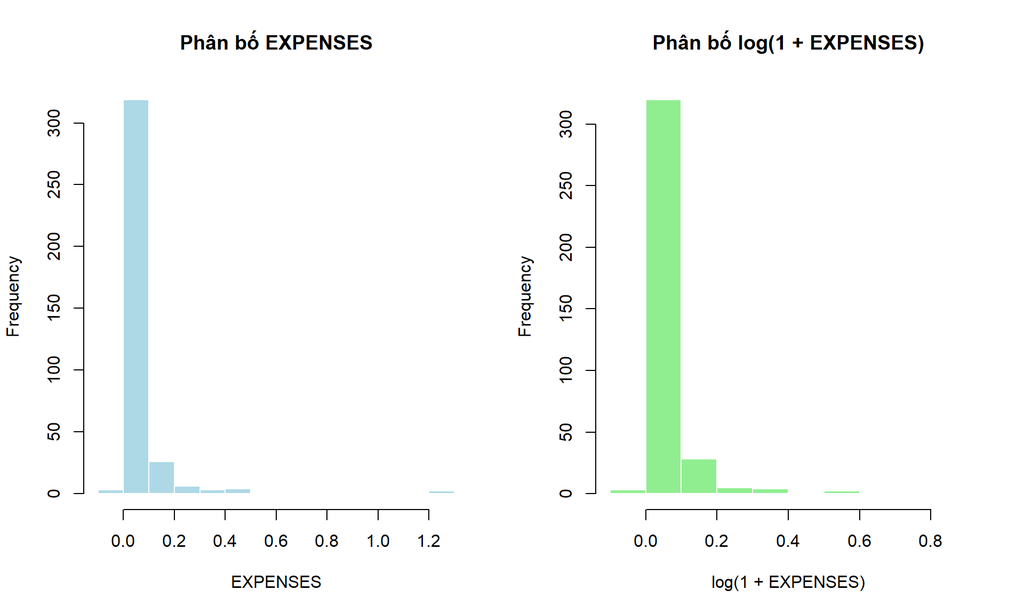

```r
# Phân bố của biến mục tiêu trước và sau khi biến đổi
par(mfrow = c(1, 2))
hist(
  data_ins$EXPENSES,
  main = "Phân bố EXPENSES",
  xlab = "EXPENSES",
  col = "lightblue",
  border = "white"
)
hist(
  log1p(data_ins$EXPENSES),
  main = "Phân bố log(1 + EXPENSES)",
  xlab = "log(1 + EXPENSES)",
  col = "lightgreen",
  border = "white"
)
```

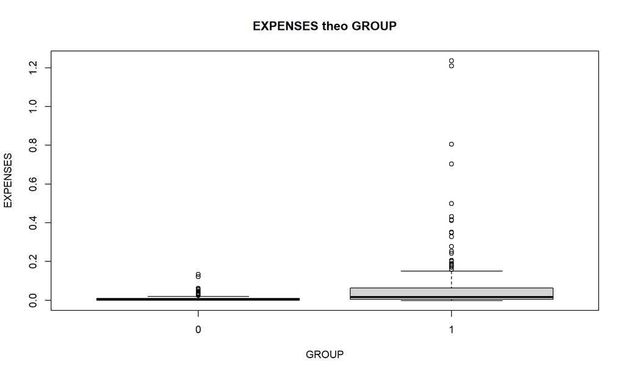

```r
par(mfrow = c(1, 1))

# So sánh chi phí giữa các nhóm công ty
boxplot(
  EXPENSES ~ GROUP,
  data = data_ins,
  main = "EXPENSES theo GROUP",
  xlab = "GROUP",
  ylab = "EXPENSES",
  col = "lightgray"
)
```

**Nhận xét:** Nếu phân bố EXPENSES lệch phải và có một số quan sát lớn, phép biến đổi $\log(1+u)$ giúp giảm ảnh hưởng của giá trị cực đoan và thường làm phần dư ổn định hơn. Việc dùng $\log(1+u)$ thay cho $\log(u)$ còn cho phép xử lý các giá trị bằng 0 và những giá trị âm nhỏ lớn hơn $-1$.

### 1.3. Chia train/test và biến đổi dữ liệu

Dữ liệu được chia ngẫu nhiên thành 80% dùng để ước lượng mô hình và 20% dùng để đánh giá ngoài mẫu. Việc chia dữ liệu được thực hiện **trước khi đánh giá mô hình**, giúp kết quả test phản ánh tốt hơn khả năng dự báo cho công ty chưa xuất hiện trong mẫu huấn luyện.

```r
set.seed(23110054)
train_index <- sample(
  seq_len(nrow(data_ins)),
  size = floor(0.80 * nrow(data_ins))
)

train_raw <- data_ins[train_index, ]
test_raw  <- data_ins[-train_index, ]

x_continuous <- c(
  "STAFFWAGE", "AGENTWAGE", "LONGLOSS", "SHORTLOSS",
  "GPWPERSONAL", "GPWCOMM", "ASSETS", "CASH"
)

# Hàm tạo các biến log nhưng vẫn giữ nguyên dữ liệu gốc
transform_insurance_data <- function(df, group_levels) {
  result <- df
  result$GROUP <- factor(result$GROUP, levels = group_levels)
  result$LNEXPENSES <- log1p(result$EXPENSES)

  for (v in x_continuous) {
    result[[paste0("LN_", v)]] <- log1p(result[[v]])
  }

  result
}

group_levels <- levels(data_ins$GROUP)
train_model <- transform_insurance_data(train_raw, group_levels)
test_model  <- transform_insurance_data(test_raw, group_levels)

cat("Số quan sát train:", nrow(train_model), "\n")
```

```
## Số quan sát train: 292
```

```r
cat("Số quan sát test:", nrow(test_model), "\n")
```

```
## Số quan sát test: 73
```

```r
# Tương quan giữa biến mục tiêu và các biến giải thích đã biến đổi
log_predictors <- paste0("LN_", x_continuous)
cor_matrix <- cor(
  train_model[, c("LNEXPENSES", log_predictors)],
  use = "complete.obs"
)

cor_with_expenses <- sort(
  cor_matrix["LNEXPENSES", log_predictors],
  decreasing = TRUE
)
print(round(cor_with_expenses, 4))
```

```
##   LN_SHORTLOSS    LN_LONGLOSS     LN_GPWCOMM      LN_ASSETS        LN_CASH
##         0.9394         0.9152         0.8814         0.8605         0.8569
## LN_GPWPERSONAL   LN_STAFFWAGE   LN_AGENTWAGE
##         0.8160         0.0794         0.0667
```

### 1.4. Xây dựng, so sánh và lựa chọn mô hình

Hai mô hình được xem xét:

- **Full model:** sử dụng toàn bộ biến giải thích, bao gồm CASH.
- **Reduced model:** giữ cấu trúc của mô hình ban đầu và loại CASH để kiểm tra liệu biến này có cải thiện dự báo hay không.

Để không dùng tập test cho việc lựa chọn mô hình, ta thực hiện **5-fold cross-validation trên tập train**. Mô hình có CV-RMSE thấp hơn được chọn, sau đó mới đánh giá một lần trên tập test độc lập.

```r
full_formula <- LNEXPENSES ~ GROUP + LN_STAFFWAGE + LN_AGENTWAGE +
  LN_LONGLOSS + LN_SHORTLOSS + LN_GPWPERSONAL + LN_GPWCOMM +
  LN_ASSETS + LN_CASH

reduced_formula <- LNEXPENSES ~ GROUP + LN_STAFFWAGE + LN_AGENTWAGE +
  LN_LONGLOSS + LN_SHORTLOSS + LN_GPWPERSONAL + LN_GPWCOMM +
  LN_ASSETS

model_full <- lm(full_formula, data = train_model)
model_reduced <- lm(reduced_formula, data = train_model)

# Smearing estimator giúp giảm sai lệch khi chuyển dự báo từ log về thang gốc
predict_original_scale <- function(model, newdata) {
  smearing_factor <- mean(exp(residuals(model)))
  prediction <- exp(predict(model, newdata = newdata)) * smearing_factor - 1
  pmax(prediction, 0)
}

metric_row <- function(model_name, actual, predicted) {
  data.frame(
    Model = model_name,
    RMSE = sqrt(mean((actual - predicted)^2)),
    MAE = mean(abs(actual - predicted)),
    R2_test = 1 - sum((actual - predicted)^2) /
      sum((actual - mean(actual))^2)
  )
}

# Tạo 5 fold theo từng GROUP để tỷ lệ nhóm giữa các fold cân bằng hơn
set.seed(23110054)
k_folds <- 5
fold_id <- integer(nrow(train_model))

for (g in levels(train_model$GROUP)) {
  group_index <- which(train_model$GROUP == g)
  fold_id[group_index] <- sample(rep(1:k_folds, length.out = length(group_index)))
}

cross_validated_rmse <- function(model_formula, data, folds) {
  cv_prediction <- rep(NA_real_, nrow(data))

  for (fold in sort(unique(folds))) {
    analysis_data <- data[folds != fold, ]
    assessment_data <- data[folds == fold, ]

    fold_model <- lm(model_formula, data = analysis_data)
    cv_prediction[folds == fold] <- predict_original_scale(
      fold_model,
      assessment_data
    )
  }

  sqrt(mean((data$EXPENSES - cv_prediction)^2))
}

cv_comparison <- data.frame(
  Model = c("Full model", "Reduced model"),
  CV_RMSE = c(
    cross_validated_rmse(full_formula, train_model, fold_id),
    cross_validated_rmse(reduced_formula, train_model, fold_id)
  ),
  Adjusted_R2_train = c(
    summary(model_full)$adj.r.squared,
    summary(model_reduced)$adj.r.squared
  ),
  AIC = c(AIC(model_full), AIC(model_reduced))
)

knitr::kable(
  cv_comparison,
  digits = 5,
  caption = "So sánh mô hình bằng 5-fold cross-validation trên tập train"
)
```

So sánh mô hình bằng 5-fold cross-validation trên tập train

| Model | CV_RMSE | Adjusted_R2_train | AIC |
| --- | --- | --- | --- |
| Full model | 0.03998 | 0.94208 | -1351.844 |
| Reduced model | 0.04048 | 0.94163 | -1350.515 |

```r
best_model_name <- cv_comparison$Model[which.min(cv_comparison$CV_RMSE)]

if (best_model_name == "Full model") {
  final_model <- model_full
} else {
  final_model <- model_reduced
}

cat("Mô hình được chọn theo CV-RMSE:", best_model_name, "\n\n")
```

```
## Mô hình được chọn theo CV-RMSE: Full model
```

```r
summary(final_model)
```

```
##
## Call:
## lm(formula = full_formula, data = train_model)
##
## Residuals:
##       Min        1Q    Median        3Q       Max
## -0.118834 -0.002560 -0.000249  0.002010  0.114336
##
## Coefficients:
##                  Estimate Std. Error t value Pr(>|t|)
## (Intercept)     0.0057424  0.0545869   0.105 0.916294
## GROUP1         -0.0016442  0.0030831  -0.533 0.594235
## LN_STAFFWAGE   -0.0014863  0.0162894  -0.091 0.927363
## LN_AGENTWAGE    0.0003778  0.0190783   0.020 0.984214
## LN_LONGLOSS     0.3481802  0.0547632   6.358 8.21e-10 ***
## LN_SHORTLOSS    0.3361683  0.0374303   8.981  < 2e-16 ***
## LN_GPWPERSONAL  0.0865749  0.0229688   3.769 0.000199 ***
## LN_GPWCOMM      0.1048029  0.0193712   5.410 1.35e-07 ***
## LN_ASSETS      -0.0571068  0.0527225  -1.083 0.279663
## LN_CASH         0.0936056  0.0520604   1.798 0.073244 .
## ---
## Signif. codes:  0 '***' 0.001 '**' 0.01 '*' 0.05 '.' 0.1 ' ' 1
##
## Residual standard error: 0.02342 on 282 degrees of freedom
## Multiple R-squared:  0.9439, Adjusted R-squared:  0.9421
## F-statistic: 526.9 on 9 and 282 DF,  p-value: < 2.2e-16
```

```r
# Chỉ sau khi chọn xong mô hình mới đánh giá trên tập test
baseline_prediction <- rep(mean(train_raw$EXPENSES), nrow(test_raw))
final_test_prediction <- predict_original_scale(final_model, test_model)

test_comparison <- rbind(
  metric_row("Baseline: trung bình train", test_raw$EXPENSES, baseline_prediction),
  metric_row(paste("Final:", best_model_name), test_raw$EXPENSES, final_test_prediction)
)

knitr::kable(
  test_comparison,
  digits = 5,
  caption = "Đánh giá cuối cùng trên tập test chưa được dùng để chọn mô hình"
)
```

Đánh giá cuối cùng trên tập test chưa được dùng để chọn mô hình

| Model | RMSE | MAE | R2_test |
| --- | --- | --- | --- |
| Baseline: trung bình train | 0.07511 | 0.04895 | -0.04432 |
| Final: Full model | 0.02218 | 0.01156 | 0.90894 |

**Cách đọc kết quả:**

- **CV-RMSE:** sai số dự báo trung bình qua 5 lần luân phiên tập validation trong dữ liệu train; càng thấp càng tốt và được dùng để chọn mô hình.
- **Adjusted $R^2$ và AIC:** cung cấp thêm thông tin về độ phù hợp trong mẫu và mức đánh đổi giữa độ phù hợp với độ phức tạp, nhưng không thay thế đánh giá dự báo ngoài mẫu.
- **RMSE test:** phạt mạnh các sai số dự báo lớn; càng thấp càng tốt.
- **MAE test:** sai số tuyệt đối trung bình trên đơn vị EXPENSES.
- **$R^2_{test}$:** có thể âm nếu mô hình dự báo kém hơn việc dùng trung bình.
- Tập test chỉ được dùng sau khi đã chọn mô hình, nhờ đó kết quả đánh giá cuối cùng đáng tin cậy hơn.

### 1.5. Kiểm tra đa cộng tuyến và chẩn đoán mô hình

```r
# Tính VIF cho các biến liên tục trong mô hình cuối cùng
final_terms <- all.vars(formula(final_model))
final_numeric_predictors <- intersect(log_predictors, final_terms)

vif_values <- sapply(final_numeric_predictors, function(target_var) {
  other_vars <- setdiff(final_numeric_predictors, target_var)
  auxiliary_formula <- reformulate(
    c("GROUP", other_vars),
    response = target_var
  )
  auxiliary_model <- lm(auxiliary_formula, data = train_model)
  1 / (1 - summary(auxiliary_model)$r.squared)
})

vif_table <- data.frame(
  Variable = names(vif_values),
  VIF = as.numeric(vif_values)
)
vif_table <- vif_table[order(vif_table$VIF, decreasing = TRUE), ]

knitr::kable(
  vif_table,
  digits = 3,
  caption = "VIF của các biến liên tục trong mô hình cuối cùng"
)
```

VIF của các biến liên tục trong mô hình cuối cùng

|  | Variable | VIF |
| --- | --- | --- |
| 7 | LN_ASSETS | 231.039 |
| 8 | LN_CASH | 209.688 |
| 3 | LN_LONGLOSS | 8.207 |
| 6 | LN_GPWCOMM | 7.649 |
| 4 | LN_SHORTLOSS | 7.128 |
| 5 | LN_GPWPERSONAL | 4.530 |
| 1 | LN_STAFFWAGE | 2.473 |
| 2 | LN_AGENTWAGE | 2.444 |

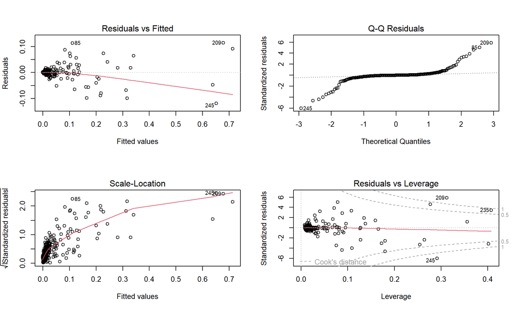

```r
# Bốn biểu đồ chẩn đoán chuẩn của mô hình tuyến tính
par(mfrow = c(2, 2))
plot(final_model)
```

```r
par(mfrow = c(1, 1))

# Quan sát có Cook's distance lớn được đánh dấu để rà soát,
# không tự động xóa nếu chưa có lý do nghiệp vụ rõ ràng.
cook_distance <- cooks.distance(final_model)
influential_rows <- which(cook_distance > 4 / nrow(train_model))

cat("Số quan sát cần rà soát theo ngưỡng Cook's distance 4/n:",
    length(influential_rows), "\n")
```

```
## Số quan sát cần rà soát theo ngưỡng Cook's distance 4/n: 24
```

```r
if (length(influential_rows) > 0) {
  influential_table <- data.frame(
    Original_Row = as.integer(rownames(train_model)[influential_rows]),
    Cooks_Distance = cook_distance[influential_rows]
  )
  print(influential_table[order(influential_table$Cooks_Distance,
                                decreasing = TRUE), ])
}
```

```
##     Original_Row Cooks_Distance
## 209          209     1.57537419
## 245          245     1.49617472
## 235          235     0.81786069
## 248          248     0.80783850
## 175          175     0.65819102
## 338          338     0.47624715
## 183          183     0.38066649
## 85            85     0.21562348
## 210          210     0.20141078
## 356          356     0.19479306
## 314          314     0.19077902
## 151          151     0.18433055
## 238          238     0.14744672
## 225          225     0.13279705
## 301          301     0.11280176
## 202          202     0.09994410
## 233          233     0.08125222
## 236          236     0.07937196
## 194          194     0.07751948
## 215          215     0.05560237
## 138          138     0.04328519
## 55            55     0.03814831
## 224          224     0.02155739
## 341          341     0.01829560
```

**Nguyên tắc đánh giá:**

- VIF lớn cho thấy các biến giải thích có thể chứa thông tin trùng lặp, làm hệ số ước lượng kém ổn định.
- Residuals vs Fitted được dùng để kiểm tra dạng quan hệ và phương sai phần dư.
- Normal Q-Q hỗ trợ đánh giá tính gần chuẩn của phần dư.
- Cook’s distance giúp phát hiện các quan sát có ảnh hưởng mạnh; các quan sát này cần được kiểm tra về mặt dữ liệu và nghiệp vụ trước khi quyết định xử lý.

### 1.6. Diễn giải theo góc nhìn kinh doanh

Không nên diễn giải hệ số của mô hình $\log(1+Y)$ theo đúng công thức của mô hình log-log thông thường mà bỏ qua số cộng 1. Để diễn giải trực quan và chính xác hơn, ta tạo một công ty đại diện, tăng GPWCOMM thêm 10%, giữ các yếu tố khác không đổi và so sánh hai mức dự báo.

```r
# Công ty đại diện: dùng trung vị của các biến liên tục và GROUP phổ biến nhất
reference_company <- train_raw[1, ]
for (v in continuous_vars) {
  reference_company[[v]] <- median(train_raw[[v]], na.rm = TRUE)
}

most_common_group <- names(sort(table(train_raw$GROUP), decreasing = TRUE))[1]
reference_company$GROUP <- factor(most_common_group, levels = group_levels)

# Kịch bản: GPWCOMM tăng 10%, các biến khác giữ nguyên
higher_gpwcomm_company <- reference_company
higher_gpwcomm_company$GPWCOMM <- reference_company$GPWCOMM * 1.10

reference_model_data <- transform_insurance_data(reference_company, group_levels)
scenario_model_data <- transform_insurance_data(higher_gpwcomm_company, group_levels)

reference_prediction <- predict_original_scale(final_model, reference_model_data)
scenario_prediction <- predict_original_scale(final_model, scenario_model_data)

scenario_result <- data.frame(
  Scenario = c("Công ty đại diện", "GPWCOMM tăng 10%"),
  Predicted_EXPENSES = c(reference_prediction, scenario_prediction)
)

knitr::kable(
  scenario_result,
  digits = 6,
  caption = "Phân tích kịch bản thay đổi GPWCOMM"
)
```

Phân tích kịch bản thay đổi GPWCOMM

| Scenario | Predicted_EXPENSES |
| --- | --- |
| Công ty đại diện | 0.006262 |
| GPWCOMM tăng 10% | 0.006513 |

```r
percent_change_expenses <- 100 *
  (scenario_prediction / reference_prediction - 1)

cat("Khi GPWCOMM tăng 10%, EXPENSES dự báo thay đổi khoảng",
    round(percent_change_expenses, 3), "% trong điều kiện các yếu tố khác giữ nguyên.\n")
```

```
## Khi GPWCOMM tăng 10%, EXPENSES dự báo thay đổi khoảng 4.001 % trong điều kiện các yếu tố khác giữ nguyên.
```

Kết quả trên thể hiện **mối liên hệ dự báo có điều kiện**, không khẳng định GPWCOMM là nguyên nhân trực tiếp làm thay đổi EXPENSES. Cách diễn giải theo kịch bản phù hợp hơn với mục tiêu hỗ trợ ra quyết định và tránh nhầm lẫn giữa tương quan với quan hệ nhân quả.

### 1.7. Dự báo cho một công ty mới

Giả sử công ty mới có LONGLOSS = 0.025, SHORTLOSS = 0.040, GPWPERSONAL = 0.050, GPWCOMM = 0.120, ASSETS = 0.400, CASH = 0.350 và GROUP = 1. STAFFWAGE và AGENTWAGE được lấy bằng trung vị của tập train để giảm ảnh hưởng của giá trị cực đoan.

```r
target_group <- if ("1" %in% group_levels) "1" else group_levels[1]

new_company_raw <- data.frame(
  EXPENSES = NA_real_,
  GROUP = factor(target_group, levels = group_levels),
  STAFFWAGE = median(train_raw$STAFFWAGE, na.rm = TRUE),
  AGENTWAGE = median(train_raw$AGENTWAGE, na.rm = TRUE),
  LONGLOSS = 0.025,
  SHORTLOSS = 0.040,
  GPWPERSONAL = 0.050,
  GPWCOMM = 0.120,
  ASSETS = 0.400,
  CASH = 0.350
)

new_company_model <- transform_insurance_data(new_company_raw, group_levels)

# Khoảng dự báo 95% trên thang log
prediction_log <- predict(
  final_model,
  newdata = new_company_model,
  interval = "prediction",
  level = 0.95
)

# Điểm dự báo dùng smearing correction; hai cận được chuyển ngược trực tiếp
smearing_factor <- mean(exp(residuals(final_model)))
forecast_result <- data.frame(
  Point_Estimate = exp(prediction_log[, "fit"]) * smearing_factor - 1,
  Prediction_Lower_95 = expm1(prediction_log[, "lwr"]),
  Prediction_Upper_95 = expm1(prediction_log[, "upr"])
)

cat("DỰ BÁO CHI PHÍ CHO CÔNG TY MỚI:\n")
```

```
## DỰ BÁO CHI PHÍ CHO CÔNG TY MỚI:
```

```r
print(forecast_result)
```

```
##   Point_Estimate Prediction_Lower_95 Prediction_Upper_95
## 1     0.04725031       -0.0004232826          0.09661596
```

**Kết luận:** Mô hình được đánh giá bằng cả độ phù hợp trong mẫu, khả năng dự báo ngoài mẫu và các biểu đồ chẩn đoán. Khoảng dự báo 95% phản ánh mức độ bất định đối với chi phí của **một công ty mới**, vì vậy cần được trình bày cùng với điểm dự báo thay vì chỉ báo cáo một con số duy nhất.

## BÀI THỰC HÀNH 2(ELECTRIC)

```r
data_elec <- read.csv("D:/Nam3/Du bao/ProjectDataset/electric-demand-australia.csv")
data_elec$date <- as.Date(data_elec$date)
```

**Tạo biến đặc trưng**

```r
data_elec$mean_temp <- (data_elec$min_temperature + data_elec$max_temperature) / 2
data_elec$temp_sq <- data_elec$mean_temp^2
```

**Chia tập train/test**

```r
train_data <- subset(data_elec, date <= "2018-12-31")
test_data  <- subset(data_elec, date >= "2019-01-01" & date <= "2019-12-31")
```

**Xây dựng Mô hình Bậc 2**

```r
M_Elec <- lm(demand ~ mean_temp + temp_sq + school_day + holiday, data = train_data)
summary(M_Elec)
```

```
##
## Call:
## lm(formula = demand ~ mean_temp + temp_sq + school_day + holiday,
##     data = train_data)
##
## Residuals:
##    Min     1Q Median     3Q    Max
## -33672  -7249   1472   7569  29085
##
## Coefficients:
##               Estimate Std. Error t value Pr(>|t|)
## (Intercept) 202723.779   2754.150  73.607  < 2e-16 ***
## mean_temp   -10145.366    327.403 -30.987  < 2e-16 ***
## temp_sq        282.509      9.245  30.558  < 2e-16 ***
## school_dayY   2892.597    629.689   4.594 4.73e-06 ***
## holidayY    -13264.173   1466.488  -9.045  < 2e-16 ***
## ---
## Signif. codes:  0 '***' 0.001 '**' 0.01 '*' 0.05 '.' 0.1 ' ' 1
##
## Residual standard error: 10230 on 1456 degrees of freedom
## Multiple R-squared:  0.4373, Adjusted R-squared:  0.4358
## F-statistic: 282.9 on 4 and 1456 DF,  p-value: < 2.2e-16
```

**Dự báo và Đánh giá (Năm 2019)**

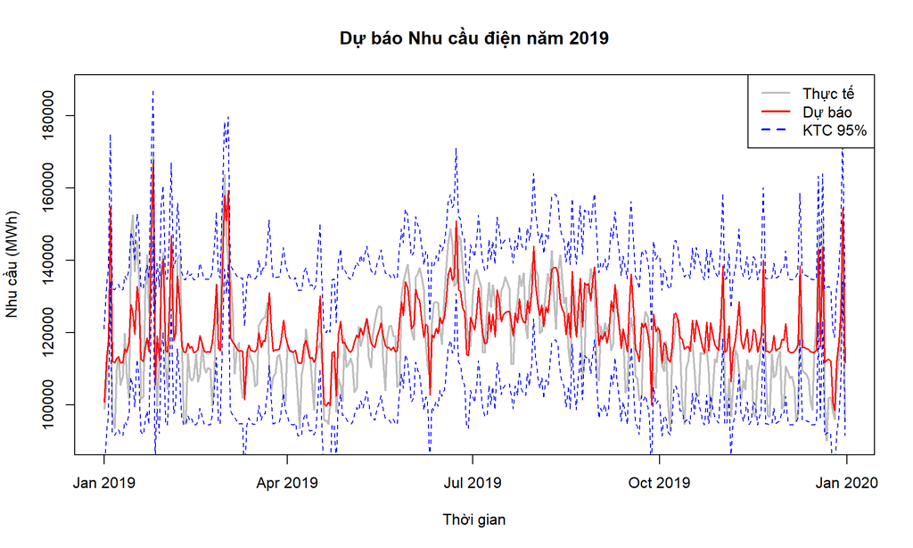

```r
predictions <- predict(M_Elec, newdata = test_data, interval = "prediction", level = 0.95)
plot(test_data$date, test_data$demand, type = "l", col = "gray", lwd = 2,
     main = "Dự báo Nhu cầu điện năm 2019",
     xlab = "Thời gian", ylab = "Nhu cầu (MWh)",
     ylim = c(min(test_data$demand), max(predictions[,"upr"])))

lines(test_data$date, predictions[, "fit"], col = "red", lwd = 1.5)
lines(test_data$date, predictions[, "lwr"], col = "blue", lty = 2)
lines(test_data$date, predictions[, "upr"], col = "blue", lty = 2)

legend("topright", legend = c("Thực tế", "Dự báo", "KTC 95%"),
       col = c("gray", "red", "blue"), lty = c(1, 1, 2), lwd = 2)
```

**Sai số dự báo (RMSE):**

```r
rmse <- sqrt(mean((test_data$demand - predictions[, "fit"])^2))
cat("Sai số RMSE:", round(rmse, 2), "MWh")
```

```
## Sai số RMSE: 9793.39 MWh
```

## BÀI THỰC HÀNH 3

### Giới thiệu Dataset

#### Nguồn dữ liệu

- **Tên dataset**: Bitcoin Market Hourly Trends (2024-2025)
- **Nguồn**: Kaggle
- **Link**: https://www.kaggle.com/datasets/gauravkumar2525/bitcoin-market-hourly-trends-2024-2025
- **Mô tả**: Dữ liệu giá Bitcoin theo giờ từ năm 2024 đến 2025, bao gồm các thông tin về giá mở cửa (Open), giá cao nhất (High), giá thấp nhất (Low), giá đóng cửa (Close), và khối lượng giao dịch (Volume).

```r
library(tidyverse)
library(forecast)
library(tseries)
library(ggplot2)
library(gridExtra)
library(lubridate)
library(TSA)
Sys.setlocale("LC_ALL", "en_US.UTF-8")
```

```
## [1] "LC_COLLATE=en_US.UTF-8;LC_CTYPE=en_US.UTF-8;LC_MONETARY=en_US.UTF-8;LC_NUMERIC=C;LC_TIME=en_US.UTF-8"
```

```r
# Đọc dữ liệu
bitcoin_data <- read.csv("D:/Nam3/Du bao/ProjectDataset/btc_hourly_ohlcv.csv")

# Xem cấu trúc dữ liệu
str(bitcoin_data)
```

```
## 'data.frame':    8760 obs. of  6 variables:
##  $ timestamp: chr  "2024-03-16 19:00:00" "2024-03-16 20:00:00" "2024-03-16 21:00:00" "2024-03-16 22:00:00" ...
##  $ open     : num  67031 66912 67129 66243 66361 ...
##  $ high     : num  67699 67538 67241 66786 66375 ...
##  $ low      : num  66890 66740 66016 65804 64780 ...
##  $ close    : num  66912 67129 66243 66361 65301 ...
##  $ volume   : num  3262 2592 3431 2832 6594 ...
```

```r
head(bitcoin_data, 10)
```

```
##              timestamp     open     high      low    close    volume
## 1  2024-03-16 19:00:00 67030.60 67699.00 66890.20 66911.52 3261.6215
## 2  2024-03-16 20:00:00 66911.51 67538.49 66739.81 67129.19 2592.0490
## 3  2024-03-16 21:00:00 67129.19 67241.10 66015.89 66243.28 3430.9621
## 4  2024-03-16 22:00:00 66243.29 66786.44 65804.00 66361.11 2832.3171
## 5  2024-03-16 23:00:00 66361.11 66375.07 64780.00 65300.63 6594.2779
## 6  2024-03-17 00:00:00 65300.64 66305.54 65122.23 65220.55 4363.8188
## 7  2024-03-17 01:00:00 65220.55 66190.00 65220.55 66174.74 2954.8036
## 8  2024-03-17 02:00:00 66174.74 66565.00 66030.00 66364.17 1779.4647
## 9  2024-03-17 03:00:00 66364.17 66576.39 66197.43 66538.99 1092.3396
## 10 2024-03-17 04:00:00 66538.99 66560.00 66261.13 66351.76  963.5545
```

### Tiền xử lí dữ liệu

#### Kiểm tra missing values

```r
cat('Số lượng missing values trong mỗi cột:\n')
```

```
## Số lượng missing values trong mỗi cột:
```

```r
colSums(is.na(bitcoin_data))
```

```
## timestamp      open      high       low     close    volume
##         0         0         0         0         0         0
```

#### Kiểm tra duplicates

```r
cat("\nSố lượng rows bị duplicate:", sum(duplicated(bitcoin_data)), "\n")
```

```
##
## Số lượng rows bị duplicate: 0
```

#### Số lượng observations sau khi tiền xử lý

```r
cat("\nTổng số observations sau tiền xử lý:", nrow(bitcoin_data), "\n")
```

```
##
## Tổng số observations sau tiền xử lý: 8760
```

### Chuyển đổi và chuẩn bị dữ liệu

```r
#Chuyển đổi cột timestamp sang định định dạng thời gian
bitcoin_data$datetime <- as.POSIXct(bitcoin_data$timestamp,
                                    origin = "1970-01-01", tz = "UTC")

# Sắp xếp thời gian tăng dần
bitcoin_data <- bitcoin_data[order(bitcoin_data$datetime), ]

# Tạo time series từ giá Close
price_ts <- ts(bitcoin_data$close, frequency = 24)
```

### Data Visualization

#### Biểu đồ của giá close

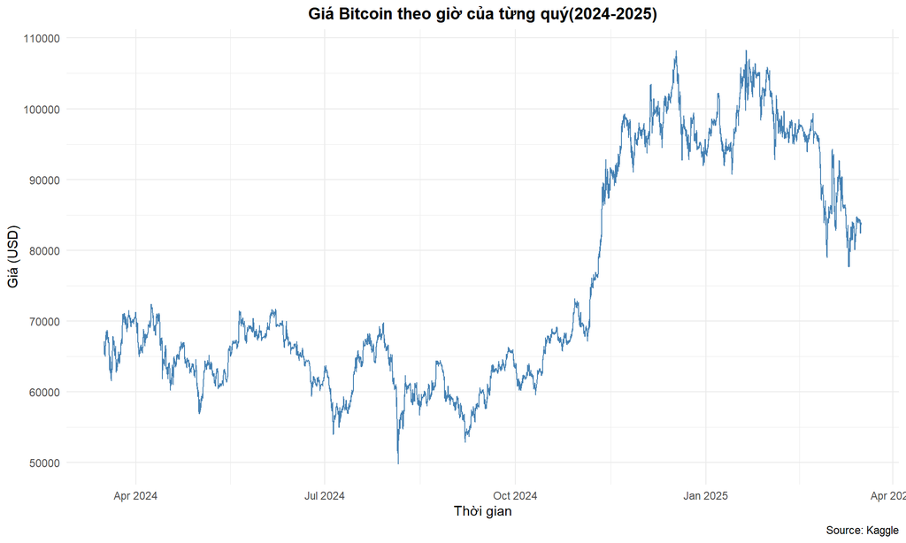

```r
library(ggplot2)
library(scales)

ggplot(bitcoin_data, aes(x = datetime, y = close)) +
  geom_line(color = "steelblue", linewidth = 0.5) +
  labs(title = "Giá Bitcoin theo giờ của từng quý(2024-2025)",
       x = "Thời gian",
       y = "Giá (USD)",
       caption = "Source: Kaggle") +
  theme_minimal() +
  theme(plot.title = element_text(hjust = 0.5, face = "bold"))
```

#### Biểu đồ về trend, seasonal, nhiễu trong 144h đầu của giá close,

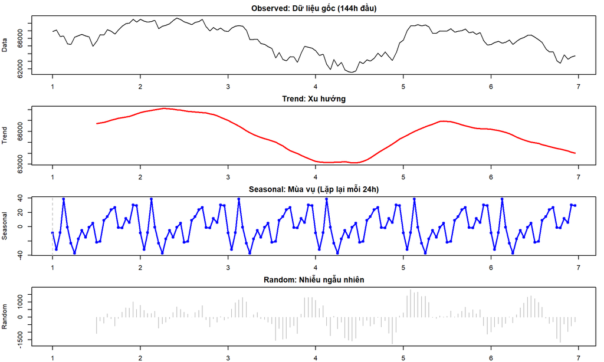

```r
decomp <- decompose(price_ts)
par(mfrow = c(4, 1), mar = c(2, 4, 2, 1))

#Dữ liệu gốc
plot(head(decomp$x, 144), type = "l", col = "black",
     main = "Observed: Dữ liệu gốc (144h đầu)", ylab = "Data")

#TREND (Xu hướng) ---
plot(head(decomp$trend, 144), type = "l", col = "red", lwd = 2,
     main = "Trend: Xu hướng", ylab = "Trend")

#SEASONAL
plot(head(decomp$seasonal, 144), type = "o", col = "blue", lwd = 2,
     main = "Seasonal: Mùa vụ (Lặp lại mỗi 24h)", ylab = "Seasonal")
abline(v = c(1, 25, 49), col = "gray", lty = 2)

#RANDOM (Nhiễu)
plot(head(decomp$random, 144), type = "h", col = "gray",
     main = "Random: Nhiễu ngẫu nhiên", ylab = "Random")
```

```r
par(mfrow = c(1, 1))
```

**NHẬN XÉT**

- **Tính xu hướng (trend)**: Quan sát biểu đồ phân rã, ta thấy thành phần Trend đóng vai trò chủ đạo, chi phối phần lớn biến động giá của Bitcoin. Xu hướng không đơn điệu (không chỉ tăng hoặc chỉ giảm) mà thay đổi theo từng giai đoạn thị trường, phản ánh tính chất biến động mạnh (high volatility) của tiền mã hóa.
- **Tính dừng (Stationarity)**: Sự hiện diện rõ rệt của Trend thay đổi theo thời gian cho thấy chuỗi dữ liệu gốc là KHÔNG DỪNG. Điều này ngụ ý rằng giá trị trung bìnhvà phương sai của chuỗi thay đổi theo thời gian.
- **Tính theo mùa (Seasonal)**: Quan sát biểu đồ phân rã ta có thể thấy rõ các hình sóng lặp lại sau mỗi 24 giờ. Mặc dù có tính quy luật, nhưng biên độ dao động của thành phần mùa vụ rất thấp (chỉ khoảng $\pm 40$ USD).So sánh với mức giá trung bình của Bitcoin trong kỳ (khoảng 60.000 - 80.000 USD), biến động do mùa vụ chỉ chiếm tỷ lệ chưa đến 0.1 nhưng vẫn cần thiết cho các dự báo ngắn hạn%.

### Xây dựng mô hình SARIMA

ACF và PACF của dữ liệu giá close gốc

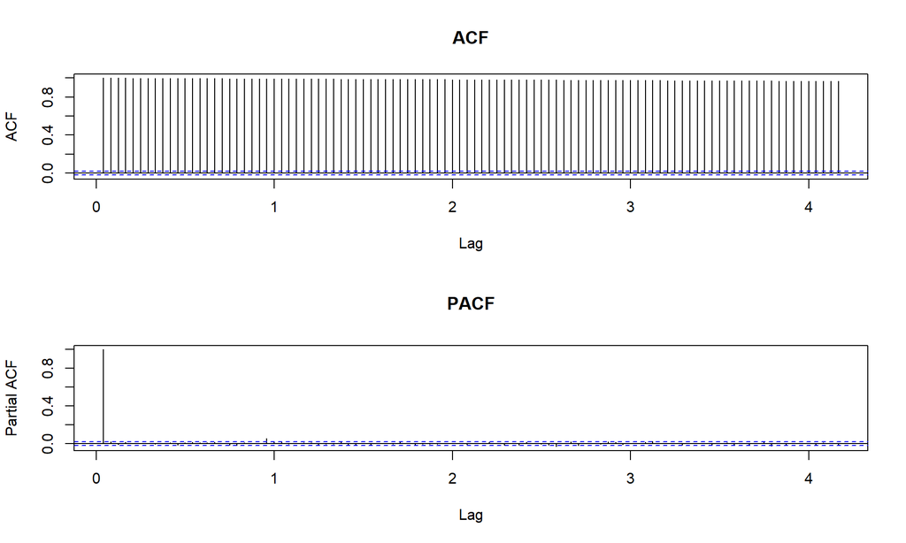

```r
par(mfrow = c(2, 1))
acf(price_ts, lag.max = 100, main = "ACF")
pacf(price_ts, lag.max = 100, main = "PACF")
```

**Nhận xét**: Dựa vào biểu đồ ACF và PACF ta thấy rõ là dữ liệu giá close gốc không dừng (non-stationary)

Ta xử lí dữ liệu để dữ liệu dừng(Stationary)

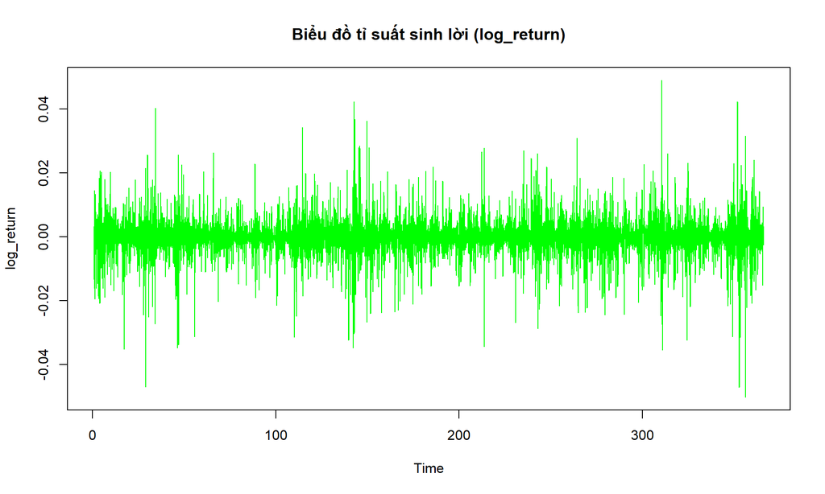

```r
log_return <- diff(log(price_ts))
plot(log_return, main = 'Biểu đồ tỉ suất sinh lời (log_return)',
     col = 'green')
```

Biểu đồ ACF và PACF của dữ liệu sau khi dừng

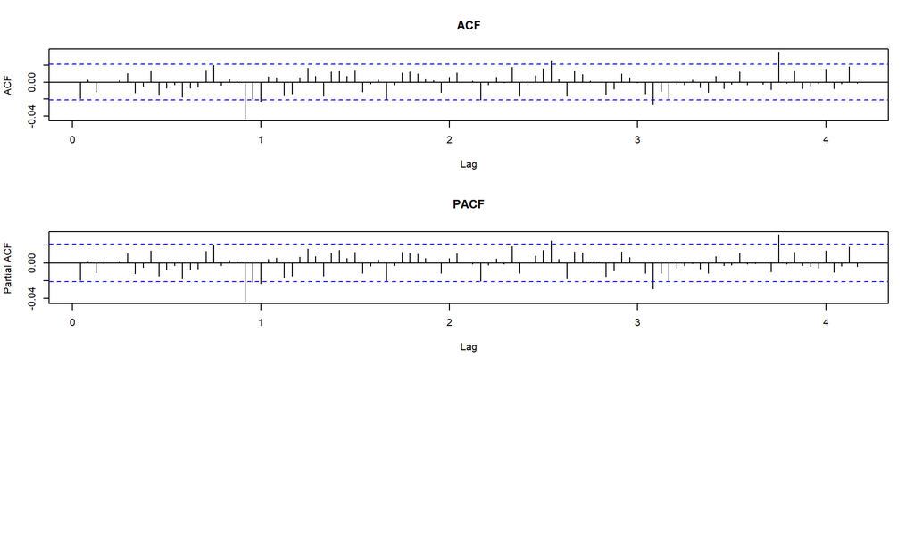

```r
par(mfrow = c(3, 1))
acf(log_return,main = 'ACF',100)
pacf(log_return,main = 'PACF',100)
```

Dự đoán mô hình SARIMA:

```r
model <- auto.arima(log_return,
                         seasonal =TRUE,
                         stepwise = TRUE,
                         approximation = FALSE,
                         trace = TRUE)
```

```
##
##  ARIMA(2,0,2)(1,0,1)[24] with non-zero mean : Inf
##  ARIMA(0,0,0)            with non-zero mean : -65567.79
##  ARIMA(1,0,0)(1,0,0)[24] with non-zero mean : Inf
##  ARIMA(0,0,1)(0,0,1)[24] with non-zero mean : -65571.63
##  ARIMA(0,0,0)            with zero mean     : -65569.61
##  ARIMA(0,0,1)            with non-zero mean : -65569.09
##  ARIMA(0,0,1)(1,0,1)[24] with non-zero mean : -65569.65
##  ARIMA(0,0,1)(0,0,2)[24] with non-zero mean : -65569.92
##  ARIMA(0,0,1)(1,0,0)[24] with non-zero mean : -65571.68
##  ARIMA(0,0,1)(2,0,0)[24] with non-zero mean : -65569.93
##  ARIMA(0,0,1)(2,0,1)[24] with non-zero mean : Inf
##  ARIMA(0,0,0)(1,0,0)[24] with non-zero mean : -65570.26
##  ARIMA(1,0,1)(1,0,0)[24] with non-zero mean : Inf
##  ARIMA(0,0,2)(1,0,0)[24] with non-zero mean : -65569.69
##  ARIMA(1,0,2)(1,0,0)[24] with non-zero mean : Inf
##  ARIMA(0,0,1)(1,0,0)[24] with zero mean     : -65573.49
##  ARIMA(0,0,1)            with zero mean     : -65570.91
##  ARIMA(0,0,1)(2,0,0)[24] with zero mean     : -65571.75
##  ARIMA(0,0,1)(1,0,1)[24] with zero mean     : -65571.46
##  ARIMA(0,0,1)(0,0,1)[24] with zero mean     : -65573.44
##  ARIMA(0,0,1)(2,0,1)[24] with zero mean     : Inf
##  ARIMA(0,0,0)(1,0,0)[24] with zero mean     : -65572.08
##  ARIMA(1,0,1)(1,0,0)[24] with zero mean     : Inf
##  ARIMA(0,0,2)(1,0,0)[24] with zero mean     : -65571.5
##  ARIMA(1,0,0)(1,0,0)[24] with zero mean     : -65573.69
##  ARIMA(1,0,0)            with zero mean     : -65570.93
##  ARIMA(1,0,0)(2,0,0)[24] with zero mean     : -65571.75
##  ARIMA(1,0,0)(1,0,1)[24] with zero mean     : Inf
##  ARIMA(1,0,0)(0,0,1)[24] with zero mean     : -65573.45
##  ARIMA(1,0,0)(2,0,1)[24] with zero mean     : Inf
##  ARIMA(2,0,0)(1,0,0)[24] with zero mean     : -65571.53
##  ARIMA(2,0,1)(1,0,0)[24] with zero mean     : Inf
##
##  Best model: ARIMA(1,0,0)(1,0,0)[24] with zero mean
```

Ta dự đoán các model có thể xảy ra

```r
model_1 <- Arima(log_return,order = c(1,0,1))
model_2 <- Arima(log_return,order = c(2,0,1))
model_3 <- Arima(log_return,order = c(2,0,2))
model_4 <- Arima(log_return, order = c(1,0,2))
model_5 <- Arima(log_return, order = c(0,0,1))
```

Các hệ số của SARIMA(1,0,0)(1,0,0)[24] và các model ta dự đoán

```r
library(forecast)
library(knitr)

models_list <- list(model, model_1, model_2, model_3, model_4, model_5)

model_names <- c("SARIMA(1,0,0)(1,0,0)[24]",
                 "ARIMA(1,0,1)",
                 "ARIMA(2,0,1)",
                 "ARIMA(2,0,2)",
                 "ARIMA(1,0,2)",
                 "ARIMA(0,0,1)")

# Tạo data frame và xử lý hiển thị Sigma2
comparison_df <- data.frame(
  Model = model_names,
  AIC = sapply(models_list, AIC),
  BIC = sapply(models_list, BIC),
  LogLik = sapply(models_list, function(m) as.numeric(logLik(m))),
  # Sử dụng format khoa học (e) để thấy các số nhỏ như 3.28e-05 thay vì 0.000
  Sigma2 = sapply(models_list, function(m) formatC(m$sigma2, format = "e", digits = 2)),
  Parameters = sapply(models_list, function(m) length(coef(m)))
)

#Sắp xếp theo AIC (thấp nhất là tốt nhất)
comparison_df <- comparison_df[order(as.numeric(comparison_df$AIC)), ]

#In kết quả
kable(comparison_df,
      digits = 3,
      caption = "Bảng so sánh các mô hình trên dữ liệu Log Return",
      row.names = FALSE)
```

Bảng so sánh các mô hình trên dữ liệu Log Return

| Model | AIC | BIC | LogLik | Sigma2 | Parameters |
| --- | --- | --- | --- | --- | --- |
| SARIMA(1,0,0)(1,0,0)[24] | -65573.70 | -65552.46 | 32789.85 | 3.28e-05 | 2 |
| ARIMA(0,0,1) | -65569.10 | -65547.86 | 32787.55 | 3.28e-05 | 2 |
| ARIMA(1,0,1) | -65567.10 | -65538.79 | 32787.55 | 3.28e-05 | 3 |
| ARIMA(2,0,1) | -65565.14 | -65529.75 | 32787.57 | 3.28e-05 | 4 |
| ARIMA(1,0,2) | -65565.14 | -65529.75 | 32787.57 | 3.28e-05 | 4 |
| ARIMA(2,0,2) | -65563.87 | -65521.41 | 32787.94 | 3.28e-05 | 5 |

**Kết quả** Nhìn vào bảng so sánh thì ta thấy rõ mô hình SARIMA(1,0,0)(1,0,0)[24] có AIC thấp hơn nên ta sẽ chọn mô hình này. Sau đó ta sẽ đi kiểm định phần dư để đảm bảo mô hình đã khai thác hết thông tin từ dữ liệu cũng như tránh được những sai sót không đáng có

```r
final_model <- model
print(final_model)
```

```
## Series: log_return
## ARIMA(1,0,0)(1,0,0)[24] with zero mean
##
## Coefficients:
##           ar1     sar1
##       -0.0195  -0.0228
## s.e.   0.0217   0.0211
##
## sigma^2 = 3.281e-05:  log likelihood = 32789.85
## AIC=-65573.7   AICc=-65573.69   BIC=-65552.46
```

```r
print(final_model$sigma2)
```

```
## [1] 3.281091e-05
```

Mô hình SARIMA(1,0,0)(1,0,0)[24] được viết dưới dạng:

$$(1 + 0.0195B)(1 + 0.0228B^{24})r_t = \ W_t$$
$$
$$\begin{aligned}
&\text{1. Khai triển toán tử lùi cho } r_t: \\
&(1 + 0.0195B)(1 + 0.0228B^{24})r_t = W_t \\
&\Leftrightarrow (1 + 0.0195B + 0.0228B^{24} + 0.0004446B^{25})r_t =
W_t \\
&\Leftrightarrow r_t = -0.0195r_{t-1} - 0.0228r_{t-24} -
0.0004446r_{t-25} + W_t \\
\\
&\text{2. Thế } r_t = \ln(X_t) - \ln(X_{t-1}) \text{ và giải cho }
\ln(X_t): \\
&\ln(X_t) - \ln(X_{t-1}) = -0.0195(\ln(X_{t-1}) - \ln(X_{t-2})) -
0.0228(\ln(X_{t-24}) - \ln(X_{t-25})) \\
&\quad \quad \quad \quad \quad \quad - 0.0004446(\ln(X_{t-25}) -
\ln(X_{t-26})) + W_t \\
&\Rightarrow \ln(X_t) = 0.9805\ln(X_{t-1}) + 0.0195\ln(X_{t-2}) -
0.0228\ln(X_{t-24}) \\
&\quad \quad \quad \quad \quad + 0.0223554\ln(X_{t-25}) +
0.0004446\ln(X_{t-26}) + W_t \\
\\
&\text{3. Suy ra phương trình giá trị gốc } X_t: \\
& X_t = X_{t-1}^{0.9805} \cdot X_{t-2}^{0.0195} \cdot
X_{t-24}^{-0.0228} \cdot X_{t-25}^{0.0223554} \cdot X_{t-26}^{0.0004446}
\cdot e^{W_t}
\end{aligned}$$

### Phân tích residuals

Biểu đồ phần dư với thời gian

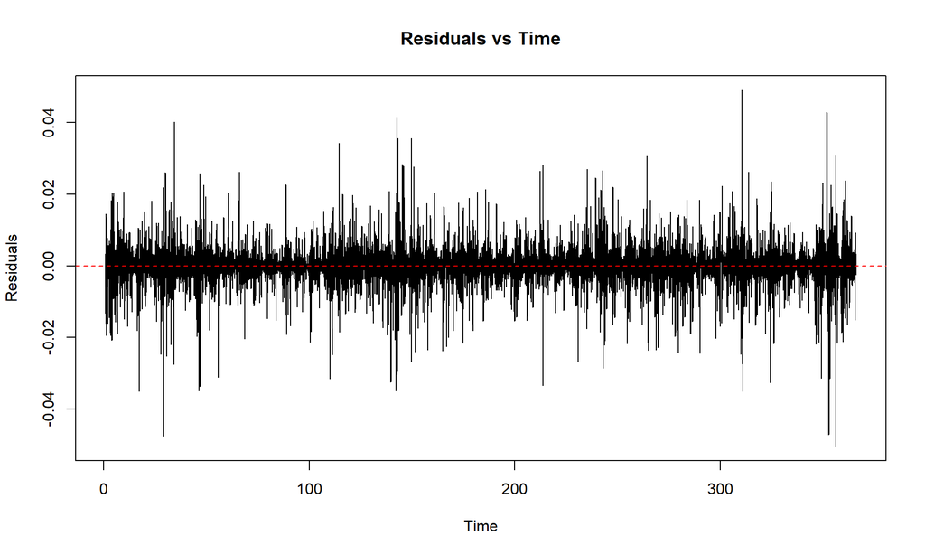

```r
plot(residuals(final_model), type = 'l',
     main = "Residuals vs Time",
     ylab = "Residuals", xlab = "Time")
abline(h = 0, col = "red", lty = 2)
```

**Biểu đồ ACF và PACF của residuals**

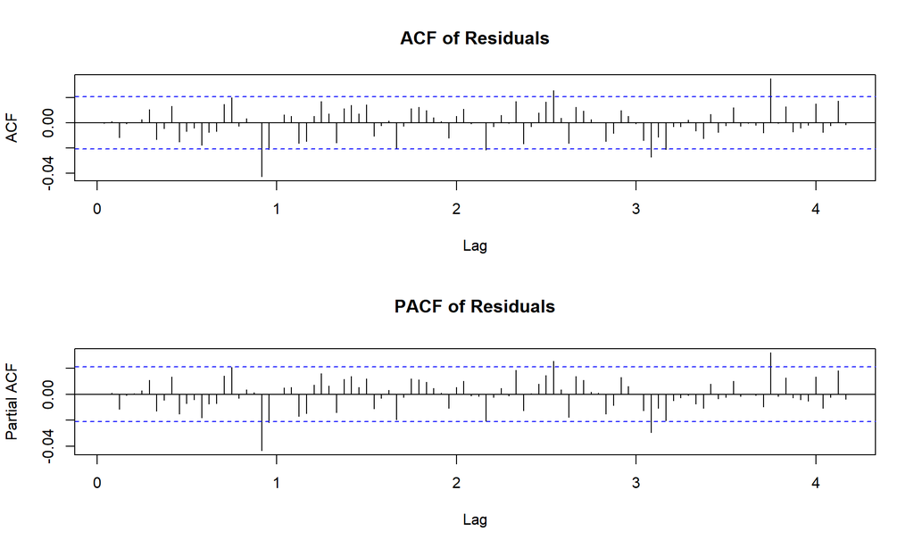

```r
par(mfrow = c(2, 1))
acf(residuals(final_model), lag.max = 100,
    main = "ACF of Residuals")
pacf(residuals(final_model), lag.max = 100,
     main = "PACF of Residuals")
```

```r
check_correlation_residuals <- Box.test(residuals(final_model))
print(check_correlation_residuals)
```

```
##
##  Box-Pierce test
##
## data:  residuals(final_model)
## X-squared = 0.00062933, df = 1, p-value = 0.98
```

**Kết luận**: Residuals gần như là white noise, mô hình SARIMA(1,0,0)(1,0,0)[24] đã đáp ứng đầy đủ thông tin trong dữ liệu.

### Dự báo giá close của Bitcoin trong **24h và 48h** sắp tới

```r
forecast_log_return <- forecast(final_model,h=48, level = 95)
# Lấy giá Bitcoin cuối cùng (giờ 366) làm mốc
last_price <- tail(bitcoin_data$close, 1)

# Chuyển đổi toàn bộ dải dự báo 48h về USD
forecast_48h <- last_price * exp(cumsum(as.numeric(forecast_log_return$mean)))

# Chuyển đổi cả khoảng tin cậy để vẽ biểu đồ "hình phễu"
lower_usd <- last_price * exp(cumsum(forecast_log_return$lower[, "95%"]))
upper_usd <- last_price * exp(cumsum(forecast_log_return$upper[, "95%"]))

# Tạo bảng tổng hợp dự báo giá Bitcoin trong 48 giờ tới
bang_du_bao <- data.frame(
  Gio = 1:48,
  Gia_du_bao = round(as.numeric(forecast_48h), 2),
  Lower_95 = round(as.numeric(lower_usd), 2),
  Upper_95 = round(as.numeric(upper_usd), 2)
)

# In bảng ra màn hình
print(bang_du_bao)
```

```
##    Gio Gia_du_bao Lower_95  Upper_95
## 1    1   83704.22 82769.74  84649.24
## 2    2   83702.11 81843.46  85602.97
## 3    3   83702.13 80929.60  86569.64
## 4    4   83702.26 80026.06  87547.35
## 5    5   83703.26 79133.42  88537.01
## 6    6   83705.19 78251.60  89538.85
## 7    7   83713.92 77385.91  90559.39
## 8    8   83711.72 76519.79  91579.60
## 9    9   83703.40 75657.84  92604.54
## 10  10   83701.67 74811.48  93648.31
## 11  11   83701.98 73976.40  94706.16
## 12  12   83705.77 73153.68  95779.95
## 13  13   83704.73 72335.93  96860.31
## 14  14   83704.85 71528.33  97954.23
```

[output cut: 34 more lines]

#### Giá close và khoảng tin cậy của Bitcoin trong **24h** sắp tới

```r
val_24   <- forecast_48h[24]
cat("\n Giá dự báo của bitcoin 24 giờ tiếp theo ",val_24, "USD")
```

```
##
##  Giá dự báo của bitcoin 24 giờ tiếp theo  83717.74 USD
```

```r
lower <- lower_usd[24]
upper <- upper_usd[24]
cat("\n Khoảng tin cậy 95% trong 24 giờ sắp tới là","[",lower,",",upper,"]")
```

```
##
##  Khoảng tin cậy 95% trong 24 giờ sắp tới là [ 63940.82 , 109611.7 ]
```

#### Giá close và khoảng tin cậy của Bitcoin trong **48h** sắp tới

```r
val_48   <- forecast_48h[48]
cat("\n Giá dự báo của bitcoin 48 giờ tiếp theo ",val_48, "USD")
```

```
##
##  Giá dự báo của bitcoin 48 giờ tiếp theo  83717.38 USD
```

```r
lower <- lower_usd[48]
upper <- upper_usd[48]
cat("\n Khoảng tin cậy 95% trong 48 giờ sắp tới là","[",lower,",",upper,"]")
```

```
##
##  Khoảng tin cậy 95% trong 48 giờ sắp tới là [ 48832.12 , 143524.4 ]
```

#### Plot the data

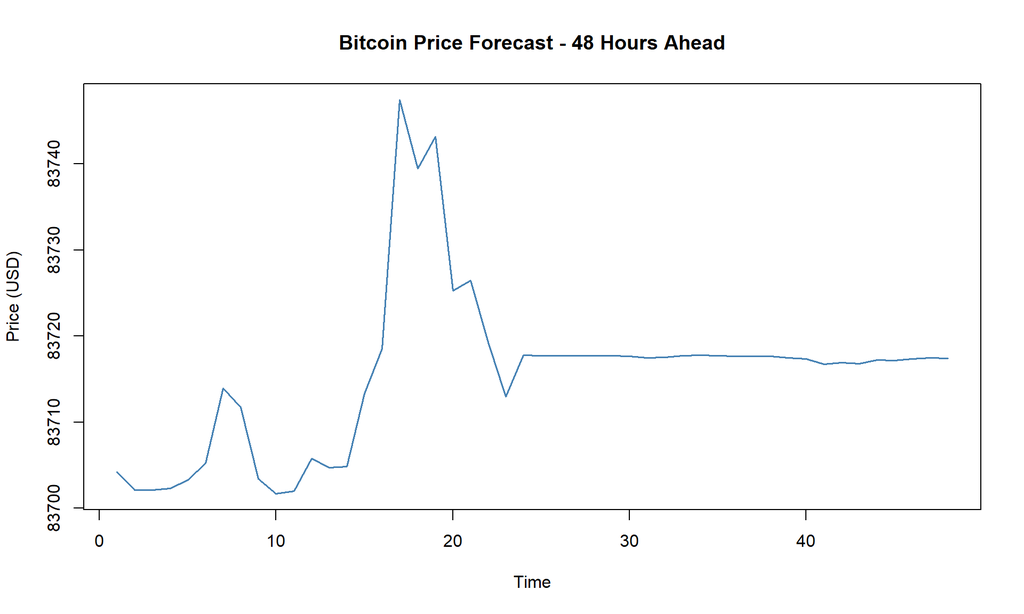

```r
plot(forecast_48h,
     main = "Bitcoin Price Forecast - 48 Hours Ahead",
     xlab = "Time",
     ylab = "Price (USD)",
     col = "steelblue",
     lwd = 1.5, type='l')
```

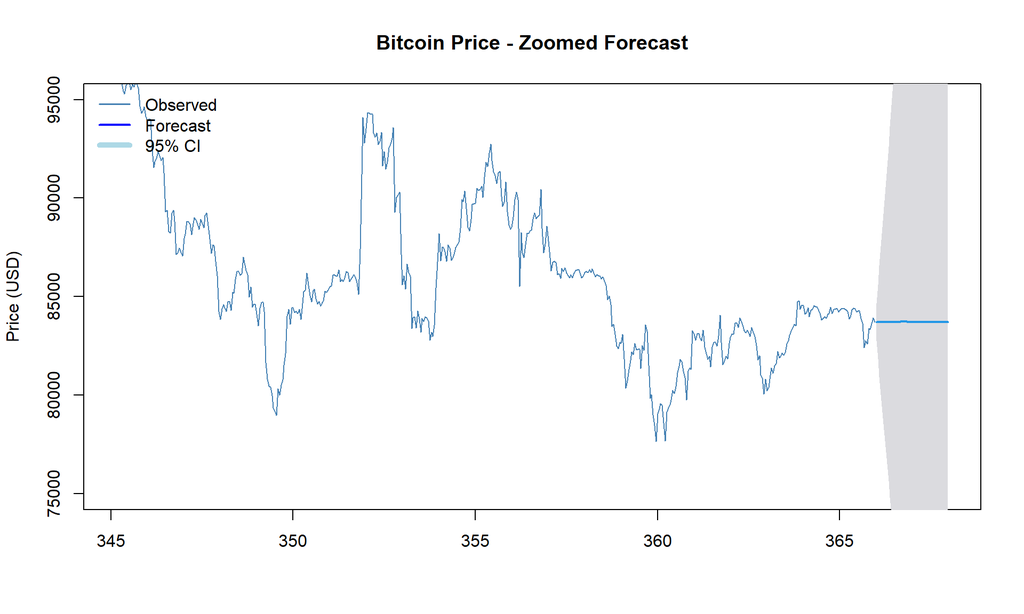

```r
forecast_usd_obj <- forecast_log_return

forecast_usd_obj$mean <- ts(as.numeric(forecast_48h),
                            start = start(forecast_log_return$mean),
                            frequency = 24)

forecast_usd_obj$lower[, "95%"] <- as.numeric(lower_usd)
forecast_usd_obj$upper[, "95%"] <- as.numeric(upper_usd)

forecast_usd_obj$x <- price_ts


par(mfrow = c(1, 1))
plot(forecast_usd_obj,
     include = 500,
     ylim = c(75000, 95000),
     main = "Bitcoin Price - Zoomed Forecast",
     ylab = "Price (USD)",
     col = "steelblue")

legend("topleft",
       legend = c("Observed", "Forecast", "95% CI"),
       col = c("steelblue", "blue", "lightblue"),
       lty = 1, lwd = c(1.5, 2, 5), bty = "n")
```

### Nhận xét mô hình

**2. Khoảng dự báo (Prediction Interval)**

- Hình phễu rủi ro: Khoảng tin cậy 95% giãn rộng mạnh sau 12 giờ do sai số tích lũy và hiệu ứng khuếch đại của hàm mũ khi chuyển đổi từ không gian Log về giá gốc.
- Giá trị thực tiễn: Độ rộng này không phải sai số mà là thước đo rủi ro trung thực, phản ánh sự bất định đặc trưng của thị trường Crypto.

**3. Hạn chế và Hướng khắc phục**

Hạn chế: Giả định phương sai hằng số (không bắt được cụm biến động - Volatility Clustering), tính tuyến tính đơn thuần và thiếu các biến ngoại sinh (tin tức, khối lượng giao dịch).

*Mô hình phù hợp cho:*

- Dự báo ngắn hạn (< 12 giờ) với CI hợp lý
- Đánh giá xu hướng tổng quát (general trend)

*Hạn chế:*

- CI rộng ở dài hạn (> 24h) do log-transformation và tích lũy sai số
- Không model được volatility clustering (hiện tượng biến động theo cụm-thời kỳ biến động mạnh thường kéo dài liên tiếp)
- Thiếu external factors (yếu tố bên ngoài): tin tức, sentiment (tâm lý thị trường), volume (khối lượng giao dịch)

*Khuyến nghị sử dụng:*

- Dùng forecast < 12h cho trading decisions (quyết định giao dịch)
- Kết hợp technical analysis (phân tích kỹ thuật) và sentiment analysis (phân tích tâm lý)
- Cân nhắc GARCH/EGARCH để thu hẹp CI và model volatility (mô hình hóa độ biến động)